# Entrega_Apple

## Modelo ARIMA

### En primer lugar realizaremos una transformaremos a logaritmo.

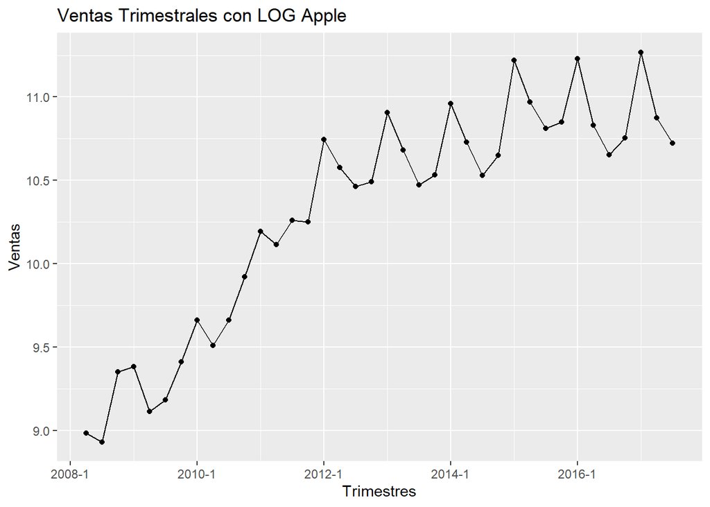

```r
zlVentas=log(zVentas)
df_newl <- data.frame(value = as.vector(zlVentas),
                     time = time(zlVentas))
ggplot(df_newl)+geom_point(aes(x=time,y=value))+geom_line(aes(x=time,y=value))+ylab("Ventas")+ggtitle("Ventas Trimestrales con LOG Apple")+xlab("Trimestres")
```

##### Podemos comprobar el claro cambio de escala y como las oscilaciones que se dan no son tan grandes.

```r
olVentas <- window(zlVentas,start=index(zlVentas[1]),end=index(zlVentas[nObs-cOmit]))
```

```r
fit1=auto.arima(olVentas,lambda=0)
summary(fit1)
```

```
## Series: olVentas
## ARIMA(0,1,0)(0,1,0)[4]
## Box Cox transformation: lambda= 0
##
## sigma^2 estimated as 0.0001455:  log likelihood=90.04
## AIC=-178.08   AICc=-177.94   BIC=-176.68
##
## Training set error measures:
##                        ME      RMSE        MAE         MPE      MAPE      MASE
## Training set -0.009433358 0.1149941 0.08310241 -0.08075189 0.8077781 0.3390024
##                    ACF1
## Training set -0.1045467
```

### Graficamos los residuos .

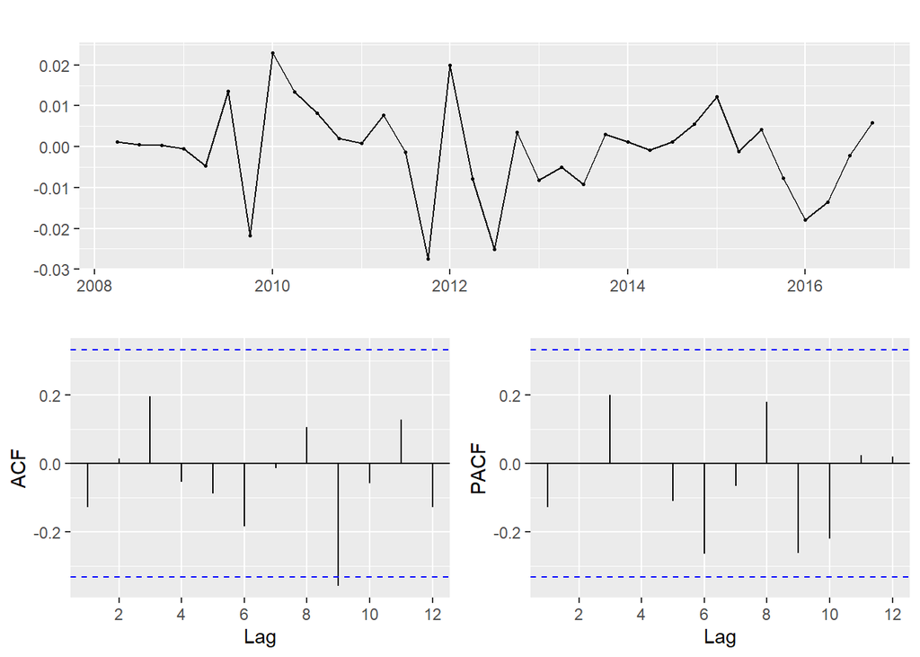

```r
ggtsdisplay(fit1$residuals)
```

#### Realizaremos un Box-Ljung Test para la comprobación de la existencia de autocorrelación dentro de esta serie.

```r
Box.test(fit1$residuals,lag=4, fitdf=3, type="Lj")
```

```
##
##  Box-Ljung test
##
## data:  fit1$residuals
## X-squared = 2.3054, df = 1, p-value = 0.1289
```

### A continuación realizamos la graficación del modelo de prediccón ARIMA.

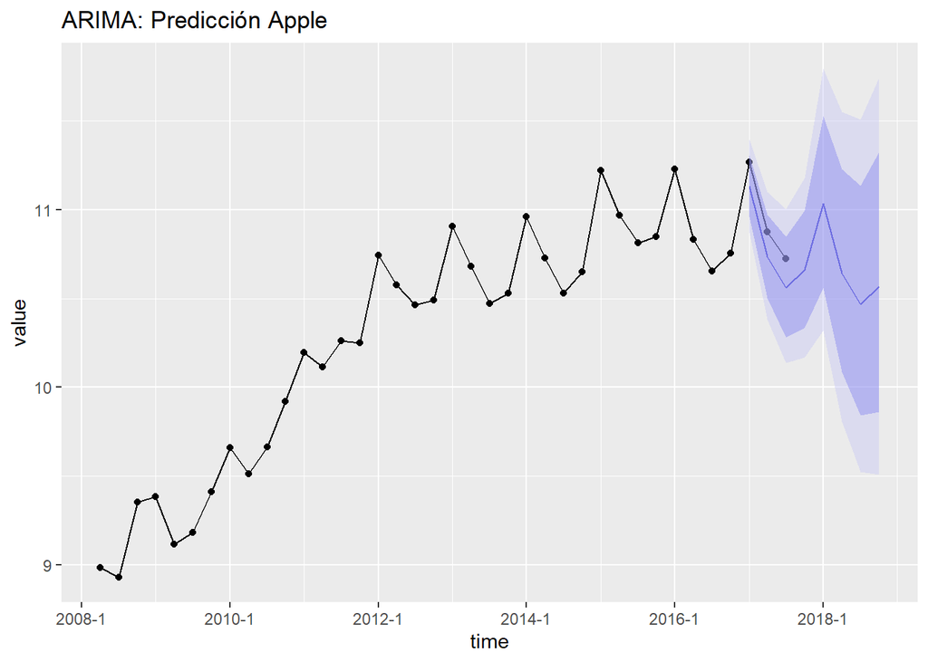

```r
fventas.arima=forecast(fit1)

ggplot(df_newl)+geom_point(aes(x=time,y=value))+geom_line(aes(x=time,y=value))+ geom_forecast(fventas.arima,alpha=0.4)+ggtitle("ARIMA: Predicción Apple")
```

#### Comprobamos como dan los valores.

```r
fventas.arima
```

```
##         Point Forecast     Lo 80    Hi 80     Lo 95    Hi 95
## 2017 Q1       11.13163 10.960855 11.30507 10.871514 11.39797
## 2017 Q2       10.73641 10.504213 10.97374 10.383335 11.10149
## 2017 Q3       10.56101 10.281957 10.84764 10.137232 11.00250
## 2017 Q4       10.66097 10.336364 10.99576 10.168550 11.17723
## 2018 Q1       11.03456 10.562433 11.52780 10.320736 11.79776
## 2018 Q2       10.64279 10.087791 11.22832  9.805807 11.55121
## 2018 Q3       10.46892  9.841112 11.13677  9.524159 11.50739
## 2018 Q4       10.56800  9.862005 11.32454  9.507570 11.74671
```

#### Comprobación de diferencias entre los valores pronosticados y los valores reales en ambos modelos.

#### Diferencias en modelo ETS.

```r
matrix(c(fventas.ets$mean[1:cOmit],zVentas[(nObs-cOmit+1):nObs]),ncol=2)
```

```
##          [,1]  [,2]
## [1,] 69439.83 78351
## [2,] 53347.98 52896
## [3,] 48972.04 45408
```

#### Diferencias en modelo ARIMA

```r
matrix(c(fventas.arima$mean[1:cOmit],zVentas[(nObs-cOmit+1):nObs]),ncol=2)
```

```
##          [,1]  [,2]
## [1,] 11.13163 78351
## [2,] 10.73641 52896
## [3,] 10.56101 45408
```

##### Se puede apreciar de forma clara como la diferencia ente los valores pronosticados y los valores reales es mucho mayor en el modelo ARIMA si lo comparamos con el modelo ETS. Esta diferencia se podrá marcar de forma numérica a acontinuación.

## Comprobación de los pronósticos de los modelos

#### Pronóstico en modelo ETS

```r
etsfit<-ets(window(tsVentas,end=2016+3/4))
fventas.ets=forecast(etsfit,h=cOmit)
forecast:::testaccuracy(fventas.ets$mean,window(tsVentas,start=2017),test = NULL, d = NULL, D = NULL)
```

```
##           ME         RMSE          MAE          MPE         MAPE         ACF1
## -9937.360471 10259.914274  9937.360471   -20.733460    20.733460    -0.500000
##    Theil's U
##     1.667969
```

#### Pronóstico en modelo ARIMA

```r
forecast:::testaccuracy(fventas.arima$mean,window(tsVentas,start=2017),test = NULL, d = NULL, D = NULL)
```

```
##           ME         RMSE          MAE          MPE         MAPE         ACF1
## 49141.065979 49283.470068 49141.065979    99.977656    99.977656    -0.500000
##    Theil's U
##     6.062669
```

##### Finalmente viendo estos datos podemos concluir que es mejor modelo predictivo el ETS en este caso. En primer lugar, el error cuadrático que posee está muy por debajo del que produce el modelo ARIMA, además de que podemos comprobar de nuevo con MAPE, que indica el error de pronóstico también vuelve a ser más grande en el modelo ARIMA. Además el coeficiente de incertidumbre en el caso del modelo ARIMA es más del triple del que poseee el modelo ETS.